# Melborune Housing Price Data Exploration

Analysis performed on the Melbourne Housing Price Data to identify major Suburbs, Number of Rooms, locations and Date of sold. In this analysis, we analysed the prime locations to buy a house, Primitive areas with the Price factors anamolies, statistics of Price variation trend.

Visualization performed to analyse the data is represented on a poster. We have utilised python to perform analyses

*This dataset provides us with several kinds of insights and if we will be able to dig deeper we will be able to predict the price of the houses depending on the data provided. In this Explainatory Data Analysis we will try to answer some few kquestions to get the idea of the data.*

### Using the dataset some objectives that can be achieve are the following:

- Is the dataset enough to predict whether a housing bubble exists.
- Which suburbs are the best to buy in?
- Where's the expensive side of town?
- Where should one buy a 2 bedroom unit for best returns?

#### For our EDA we are going to use few libraries such as:

- Pandas
- Numpy
- MatplotLib
- Seaborn
- Folium

**Importing all the required libraries**

```python
import pandas as pd
import numpy as np
import pandas_profiling
from pandas import Series, DataFrame
import matplotlib.pyplot as plt
import os
from wordcloud import WordCloud ,STOPWORDS, ImageColorGenerator
import seaborn as sns
%matplotlib inline
import folium
from folium.plugins import HeatMap
p = "YlGnBu"
p2 = "YlGn"
p3 = "Greys"
p4="viridis"
p5="coolwarm"
import datetime as dt
from sklearn.preprocessing import Imputer
from sklearn import preprocessing as pro
from pandas.plotting import scatter_matrix
import warnings
warnings.filterwarnings('ignore')
```

**Reading the Dataset**

```python
df = pd.read_csv(r"C:\Users\SA20020888\Desktop\MELBOURNE_HOUSE_PRICES_LESS.csv\Melbourne_housing_FULL.csv")
```

**Display Information about the data**

```python
df.info()
```

```
<class 'pandas.core.frame.DataFrame'>
RangeIndex: 34857 entries, 0 to 34856
Data columns (total 21 columns):
Suburb           34857 non-null object
Address          34857 non-null object
Rooms            34857 non-null int64
Type             34857 non-null object
Price            27247 non-null float64
Method           34857 non-null object
SellerG          34857 non-null object
Date             34857 non-null object
Distance         34856 non-null float64
Postcode         34856 non-null float64
Bedroom2         26640 non-null float64
Bathroom         26631 non-null float64
Car              26129 non-null float64
Landsize         23047 non-null float64
BuildingArea     13742 non-null float64
YearBuilt        15551 non-null float64
CouncilArea      34854 non-null object
Lattitude        26881 non-null float64
Longtitude       26881 non-null float64
Regionname       34854 non-null object
Propertycount    34854 non-null float64
dtypes: float64(12), int64(1), object(8)
memory usage: 5.6+ MB
```

**Column Labels**

```python
df.columns
```

```
Index(['Suburb', 'Address', 'Rooms', 'Type', 'Price', 'Method', 'SellerG',
       'Date', 'Distance', 'Postcode', 'Bedroom2', 'Bathroom', 'Car',
       'Landsize', 'BuildingArea', 'YearBuilt', 'CouncilArea', 'Lattitude',
       'Longtitude', 'Regionname', 'Propertycount'],
      dtype='object')
```

### Data Wrangling and Cleaning

**As we can see there are many categorical values which are defined as object we need to convert its data type to "Category", there is another column which contains dates of the property sold which are also not in datetime format.**

So we first convert the date column to datetime data type then we will fetch year and month from the same

```python
df['Date'] = pd.to_datetime(df['Date'])
df['Month'] = df['Date'].dt.month
df['Year'] =  df['Date'].dt.year
```

```python
category_cols = ['Type', 'Method', 'CouncilArea', 'Regionname', 'SellerG']
for i in category_cols:
    df[i] = df[i].astype('category')
```

#### Handling Missing Values

```python
df.isnull().sum()
```

```
Suburb               0
Address              0
Rooms                0
Type                 0
Price             7610
Method               0
SellerG              0
Date                 0
Distance             1
Postcode             1
Bedroom2          8217
Bathroom          8226
Car               8728
Landsize         11810
BuildingArea     21115
YearBuilt        19306
CouncilArea          3
Lattitude         7976
Longtitude        7976
Regionname           3
Propertycount        3
Month                0
Year                 0
dtype: int64
```

**As we can see there are many columns which contains null values and most importantly price column also has null values**

##### we handle these value in many ways but the simplest one is to drop all the rows corresponding to it

```python
data_priced  = df[df.Price.notnull()].drop('Address', axis = 1)
```

**Now as we looked closely we could see that there are some insignificant columns which doesnt provide any help in gettin the insights and moreover it also contains null values, so lets go ahead and drop them as well**

```python
data_priced.drop(columns = ['Distance', 'Propertycount', 'YearBuilt', 'BuildingArea', 'Car', 'Landsize', 'Bedroom2', 'Bathroom'], inplace=True)
```

```python
data_priced.dropna(axis = 0, subset=['Postcode','CouncilArea','Lattitude','Longtitude'], inplace=True)
```

##### After Handling all the missing values, lets move forward with the data cleaning.

One of the major data cleaning process is to detect all the outliers existing in the data.

- Q1 is the 25% value of all the prices dristributed over the data
- Q3 is the 75% value of all the prices dristributed over the data

IQR is the inter quartile range which contains the 50% amount of data. For detecting Outliers we use two formulas:

```python
Q1 = data_priced['Price'].quantile(0.25)
Q3 = data_priced['Price'].quantile(0.75)
IQR = Q3 - Q1
filtered = data_priced.query('(@Q1 - 1.5 * @IQR) <= Price <= (@Q3 + 1.5 * @IQR)')
filtered['PriceMillions'] = filtered['Price'].apply(lambda x: x/1000000)
```

**filtered** dataframe contains the data excluding all the outliers

**Lets compare the mean before and after removing Outliers**

```python
data_priced['Price'].mean() , filtered['Price'].mean()
```

```
(1089746.1750583528, 991633.7877728385)
```

#### We can clearly see the difference between the mean

```python
filtered.head()
```

|  | Suburb | Rooms | Type | Price | Method | SellerG | Date | Postcode | CouncilArea | Lattitude | Longtitude | Regionname | Month | Year | PriceMillions |
| --- | --- | --- | --- | --- | --- | --- | --- | --- | --- | --- | --- | --- | --- | --- | --- |
| 1 | Abbotsford | 2 | h | 1480000.0 | S | Biggin | 2016-03-12 | 3067.0 | Yarra City Council | -37.7996 | 144.9984 | Northern Metropolitan | 3 | 2016 | 1.480 |
| 2 | Abbotsford | 2 | h | 1035000.0 | S | Biggin | 2016-04-02 | 3067.0 | Yarra City Council | -37.8079 | 144.9934 | Northern Metropolitan | 4 | 2016 | 1.035 |
| 4 | Abbotsford | 3 | h | 1465000.0 | SP | Biggin | 2017-04-03 | 3067.0 | Yarra City Council | -37.8093 | 144.9944 | Northern Metropolitan | 4 | 2017 | 1.465 |
| 5 | Abbotsford | 3 | h | 850000.0 | PI | Biggin | 2017-04-03 | 3067.0 | Yarra City Council | -37.7969 | 144.9969 | Northern Metropolitan | 4 | 2017 | 0.850 |
| 6 | Abbotsford | 4 | h | 1600000.0 | VB | Nelson | 2016-04-06 | 3067.0 | Yarra City Council | -37.8072 | 144.9941 | Northern Metropolitan | 4 | 2016 | 1.600 |

#### Lets Plot the box plot to verify our assumption

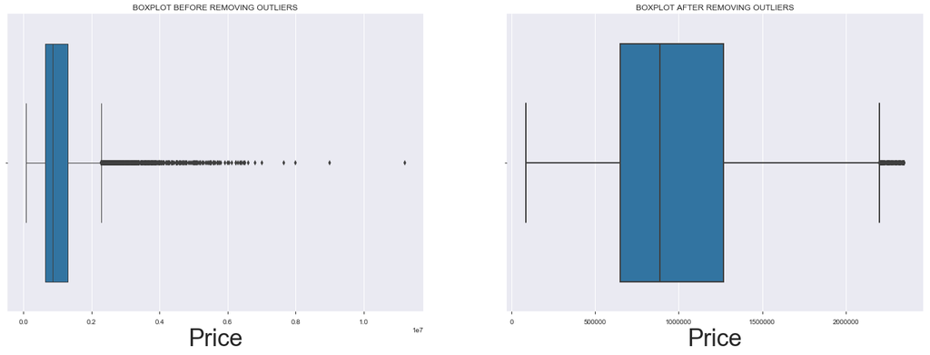

```python
fig, axs = plt.subplots(ncols=2, figsize=(24,8))
# fig = plt.figure(figsize=(20,6), dpi=105)
sns.boxplot(df['Price'], linewidth=1, ax=axs[0])
axs[0].title.set_text("BOXPLOT BEFORE REMOVING OUTLIERS")
sns.boxplot(filtered['Price'], linewidth=2)
axs[1].title.set_text("BOXPLOT AFTER REMOVING OUTLIERS")
plt.show()
```

#### Plotting the Correlation matrix to find all the relations between various variables

```python
corr_matrix = filtered.corr()
corr_matrix
```

|  | Rooms | Price | Postcode | Lattitude | Longtitude | Month | Year | PriceMillions |
| --- | --- | --- | --- | --- | --- | --- | --- | --- |
| Rooms | 1.000000 | 0.418845 | 0.079192 | 0.044351 | 0.072863 | 0.021071 | 0.188223 | 0.418845 |
| Price | 0.418845 | 1.000000 | 0.011698 | -0.229351 | 0.233019 | -0.000551 | 0.034162 | 1.000000 |
| Postcode | 0.079192 | 0.011698 | 1.000000 | -0.211213 | 0.366581 | 0.013545 | 0.112738 | 0.011698 |
| Lattitude | 0.044351 | -0.229351 | -0.211213 | 1.000000 | -0.348788 | 0.002883 | 0.039637 | -0.229351 |
| Longtitude | 0.072863 | 0.233019 | 0.366581 | -0.348788 | 1.000000 | 0.008061 | 0.036644 | 0.233019 |
| Month | 0.021071 | -0.000551 | 0.013545 | 0.002883 | 0.008061 | 1.000000 | -0.284837 | -0.000551 |
| Year | 0.188223 | 0.034162 | 0.112738 | 0.039637 | 0.036644 | -0.284837 | 1.000000 | 0.034162 |
| PriceMillions | 0.418845 | 1.000000 | 0.011698 | -0.229351 | 0.233019 | -0.000551 | 0.034162 | 1.000000 |

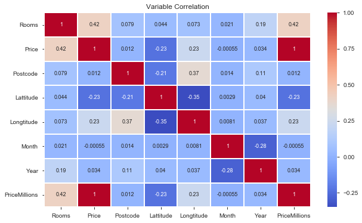

```python
plt.figure(figsize=(10,6))
sns.heatmap(corr_matrix,cmap = 'coolwarm',linewidth = 1,annot= True, annot_kws={"size": 9})
plt.title('Variable Correlation')
```

#### As we can see there is not so many strong correlations between any of the variables apart from Number of Rooms and Prices,

**So Lets Plot a Scatter matrix to visualize the relation between "Rooms" and "Price"**

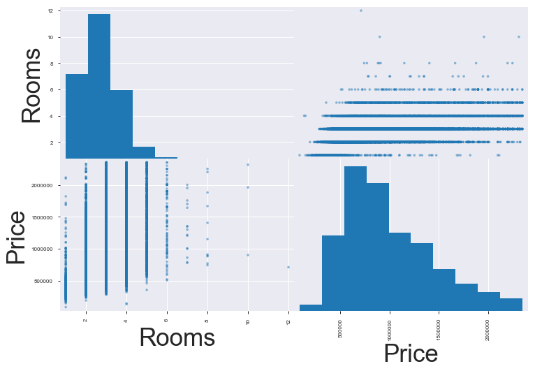

```python
attributes = ["Rooms","Price"]
scatter_matrix(filtered[attributes], figsize=(12, 8))
#plt.savefig('matrix.png')
plt.show()
```

#### Lets Plot Scatter Plot For Price over Lattitude and Longtitude to get the idea of the shape of distribution of houses over melbourne

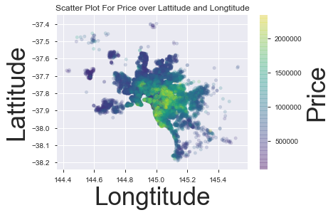

```python
fig = plt.figure(figsize=(30,10))
filtered.plot(kind="scatter", x="Longtitude", y="Lattitude", c = "Price", alpha=0.2, colorbar=True, sharex=False, cmap=plt.get_cmap("viridis"))
plt.title('Scatter Plot For Price over Lattitude and Longtitude')
plt.show()
```

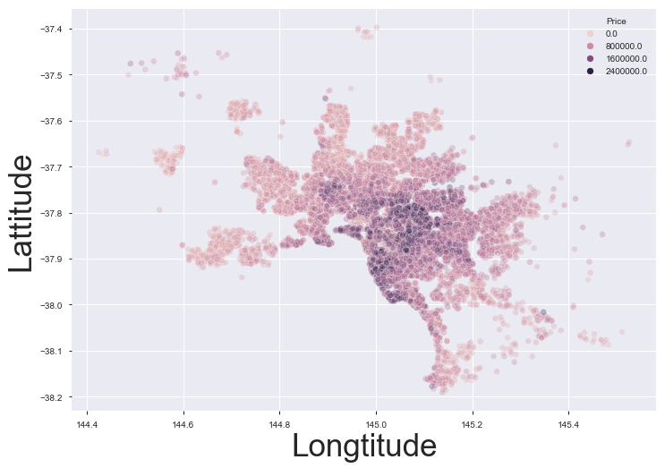

```python
# Simple scatterplot
a4_dims = (11.7, 8.27)
fig, ax = plt.subplots(figsize=a4_dims)
sns.scatterplot(y='Lattitude',
               x='Longtitude',
                alpha=0.3,
               data=filtered, ax=ax, cmap=plt.get_cmap("viridis"), hue='Price')
```

- Which suburbs are the best to buy in?

**"Best" is a very vague term and also creates the ambiguity in the buyers head as the 'Best' can be defined on the basis of the price of the house or maybe at the basis of the number of houses in the suburbs**

##### Now lets dig deeper into the concept of "Best" suburb on the basis of average price of houses of the respective Suburb

Lets get the Top 10 suburbs on the basis of average price of houses of the respective Suburb

```python
suburb_group_mean = filtered.groupby(by = 'Suburb', as_index=False).mean()
suburb_group_mean = suburb_group_mean.reset_index()
suburb_group_mean = suburb_group_mean.sort_values(by =['Price'], ascending=False, ).head(10)
# g.drop(columns=['index'], inplace = True)
suburb_group_mean.reset_index(drop=True, inplace=True)
suburb_group_mean.drop(columns=['index'], inplace = True)
lis_sub = list(suburb_group_mean['Suburb'])
```

```python
suburb_group_mean
```

|  | Suburb | Rooms | Price | Postcode | Lattitude | Longtitude | Month | Year | PriceMillions |
| --- | --- | --- | --- | --- | --- | --- | --- | --- | --- |
| 0 | Kew East | 3.411765 | 1.678456e+06 | 3102.0 | -37.793881 | 145.053080 | 7.073529 | 2016.794118 | 1.678456 |
| 1 | Albert Park | 2.590909 | 1.667371e+06 | 3206.0 | -37.844236 | 144.953147 | 6.666667 | 2016.621212 | 1.667371 |
| 2 | Balwyn North | 3.584615 | 1.652440e+06 | 3104.0 | -37.792707 | 145.085839 | 6.794872 | 2016.676923 | 1.652440 |
| 3 | Beaumaris | 3.642857 | 1.644420e+06 | 3193.0 | -37.982492 | 145.039813 | 6.857143 | 2017.250000 | 1.644420 |
| 4 | Sandringham | 3.510204 | 1.638153e+06 | 3191.0 | -37.952744 | 145.015562 | 6.959184 | 2017.163265 | 1.638153 |
| 5 | Ashburton | 3.283582 | 1.619731e+06 | 3147.0 | -37.867235 | 145.080159 | 7.268657 | 2016.597015 | 1.619731 |
| 6 | McKinnon | 3.521739 | 1.602587e+06 | 3204.0 | -37.909779 | 145.038948 | 7.434783 | 2017.173913 | 1.602587 |
| 7 | Eaglemont | 3.392857 | 1.590500e+06 | 3084.0 | -37.763034 | 145.059754 | 7.928571 | 2016.642857 | 1.590500 |
| 8 | Deepdene | 3.000000 | 1.546667e+06 | 3103.0 | -37.810400 | 145.066667 | 10.000000 | 2017.000000 | 1.546667 |
| 9 | Middle Park | 2.516129 | 1.529355e+06 | 3206.0 | -37.850536 | 144.962965 | 5.870968 | 2016.677419 | 1.529355 |

```python
suburb_group_mean = filtered[filtered["Suburb"].isin(lis_sub)]
```

**Scatter Plot for Suburb vs average price having type as a hue**

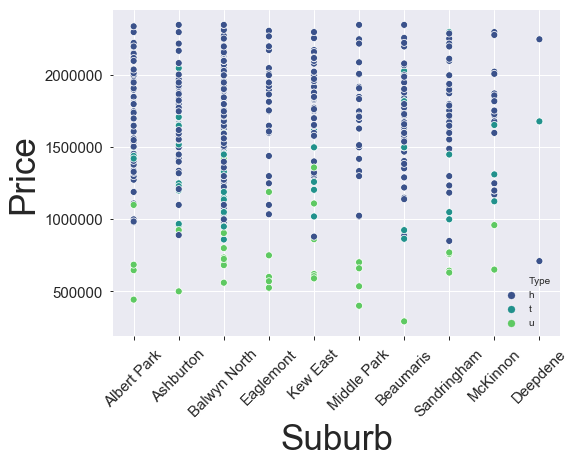

```python
fig = plt.figure(figsize=(8,6))
sns.scatterplot(x=suburb_group_mean['Suburb'],y = suburb_group_mean['Price'], palette=p4, hue=suburb_group_mean['Type'])
plt.xticks(rotation = 45)
plt.xticks(size=15)
plt.yticks(size=15)
```

**Scatter Plot for Suburb vs average price having Rooms as a hue**

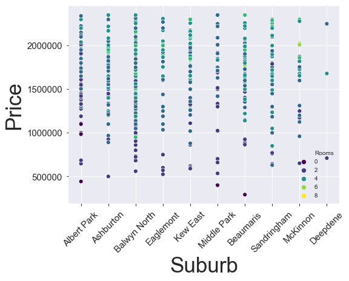

```python
fig = plt.figure(figsize=(8,6))
sns.scatterplot(x=suburb_group_mean['Suburb'],y = suburb_group_mean['Price'], palette=p4, hue=suburb_group_mean['Rooms'])
plt.xticks(rotation = 45)
plt.xticks(size=15)
plt.yticks(size=15)
```

as you can see when it comes to type **2 Rooms** are one of the most common but not the most famous ones there are very 8 rooms houses and the most common is 4 rooms houses

**Scatter Plot for Suburb vs average price on the basis of lattitude and longtitude**

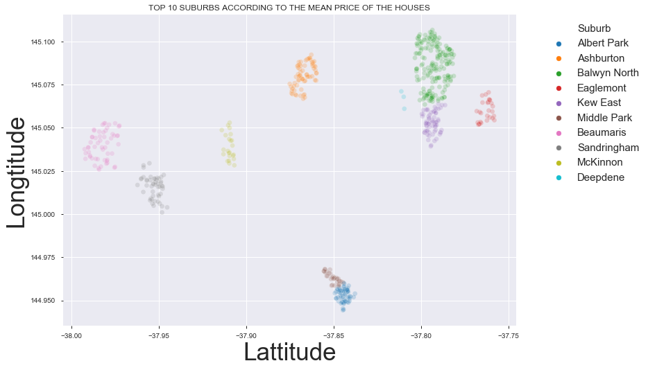

```python
# Plot districts

a4_dims = (11.7, 8.27)
fig, ax = plt.subplots(figsize=a4_dims)
sns.scatterplot(x='Lattitude',
               y='Longtitude',
                hue='Suburb',
                alpha=0.2,
               data=suburb_group_mean, ax=ax)
plt.title("TOP 10 SUBURBS ACCORDING TO THE MEAN PRICE OF THE HOUSES")
plt.legend(bbox_to_anchor=(1.05, 1), loc=2, fontsize=15)
```

##### Now lets dig deeper into the concept of "Best" suburb on the basis of Number of houses of the respective Suburb

Lets get the Top 10 suburbs on the basis of Number of price of houses of the respective Suburb

```python
suburb_group_count= filtered.groupby(by = 'Suburb', as_index=False).count()
suburb_group_count = suburb_group_count.reset_index()
suburb_group_count = suburb_group_count.sort_values(by =['Price'], ascending=False, ).head(10)
# g.drop(columns=['index'], inplace = True)
suburb_group_count.reset_index(drop=True, inplace=True)
suburb_group_count.drop(columns=['index'], inplace = True)
lis_sub = list(suburb_group_count['Suburb'])
```

```python
suburb_group_count
```

|  | Suburb | Rooms | Type | Price | Method | SellerG | Date | Postcode | CouncilArea | Lattitude | Longtitude | Regionname | Month | Year | PriceMillions |
| --- | --- | --- | --- | --- | --- | --- | --- | --- | --- | --- | --- | --- | --- | --- | --- |
| 0 | Reservoir | 500 | 500 | 500 | 500 | 500 | 500 | 500 | 500 | 500 | 500 | 500 | 500 | 500 | 500 |
| 1 | Bentleigh East | 353 | 353 | 353 | 353 | 353 | 353 | 353 | 353 | 353 | 353 | 353 | 353 | 353 | 353 |
| 2 | Richmond | 325 | 325 | 325 | 325 | 325 | 325 | 325 | 325 | 325 | 325 | 325 | 325 | 325 | 325 |
| 3 | Preston | 324 | 324 | 324 | 324 | 324 | 324 | 324 | 324 | 324 | 324 | 324 | 324 | 324 | 324 |
| 4 | Brunswick | 308 | 308 | 308 | 308 | 308 | 308 | 308 | 308 | 308 | 308 | 308 | 308 | 308 | 308 |
| 5 | Essendon | 276 | 276 | 276 | 276 | 276 | 276 | 276 | 276 | 276 | 276 | 276 | 276 | 276 | 276 |
| 6 | Coburg | 268 | 268 | 268 | 268 | 268 | 268 | 268 | 268 | 268 | 268 | 268 | 268 | 268 | 268 |
| 7 | Northcote | 265 | 265 | 265 | 265 | 265 | 265 | 265 | 265 | 265 | 265 | 265 | 265 | 265 | 265 |
| 8 | South Yarra | 232 | 232 | 232 | 232 | 232 | 232 | 232 | 232 | 232 | 232 | 232 | 232 | 232 | 232 |
| 9 | Glenroy | 226 | 226 | 226 | 226 | 226 | 226 | 226 | 226 | 226 | 226 | 226 | 226 | 226 | 226 |

```python
suburb_group_count = filtered[filtered['Suburb'].isin(lis_sub)]
```

#### Scatter Plot for Suburb vs Number of price having type as a hue

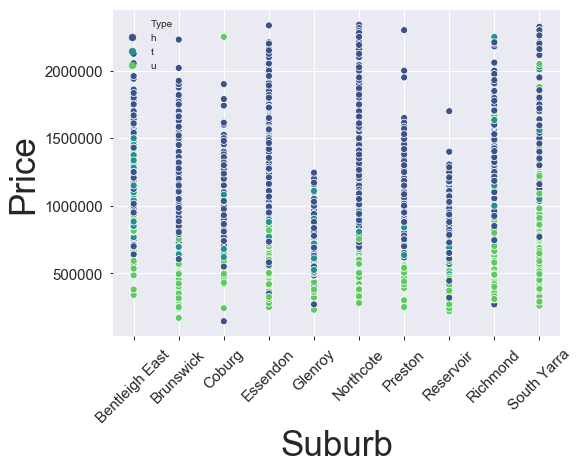

```python
fig = plt.figure(figsize=(8,6))
sns.scatterplot(x=suburb_group_count['Suburb'],y = suburb_group_count['Price'], palette=p4, hue=suburb_group_count['Type'])
plt.xticks(rotation = 45)
plt.xticks(size=15)
plt.yticks(size=15)
```

#### Scatter Plot for Suburb vs Number of price having Rooms as a hue

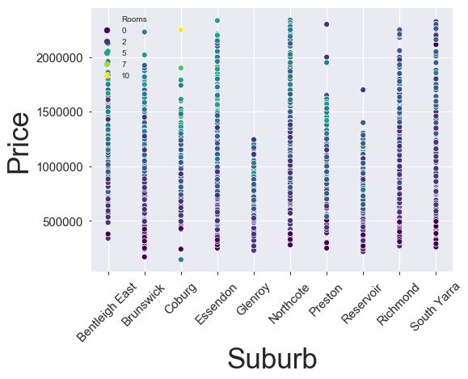

```python
fig = plt.figure(figsize=(8,6))
sns.scatterplot(x=suburb_group_count['Suburb'],y = suburb_group_count['Price'], palette=p4, hue=suburb_group_count['Rooms'])
plt.xticks(rotation = 45)
plt.xticks(size=15)
plt.yticks(size=15)
```

### -------------------------------------------------------------------------------------------------------------------------------------------------------------

**Scatter Plot for Suburb vs Number of price on the basis of lattitude and longtitude**

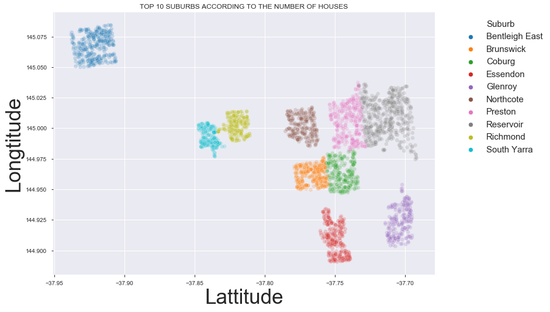

```python
# Plot districts

a4_dims = (11.7, 8.27)
fig, ax = plt.subplots(figsize=a4_dims)
sns.scatterplot(x='Lattitude',
               y='Longtitude',
                hue='Suburb',
                alpha=0.2,
               data=suburb_group_count, ax=ax)
plt.title("TOP 10 SUBURBS ACCORDING TO THE NUMBER OF HOUSES")
plt.legend(bbox_to_anchor=(1.05, 1), loc=2, fontsize=15)
```

### Great, i hope that helped you to get some insights regarding the Suburbs, Now lets plot these suburbs assumptions geographically using folium to help view things better

#### TOP 10 Suburbs vs Average Price Geographical Representation

```python
# Create basic Folium crime map
melbourne_map = folium.Map(location=[-37.840935,144.946457],
                       tiles = "Stamen Toner",
                      zoom_start = 12)

# Add data for heatmp
# data_heatmap = g[g.Year == 2017]
data_heatmap = suburb_group_mean[['Lattitude','Longtitude']]
data_heatmap = suburb_group_mean.dropna(axis=0, subset=['Lattitude','Longtitude'])
data_heatmap = [[ row['Lattitude'],row['Longtitude']] for index, row in data_heatmap.iterrows()]
HeatMap(data_heatmap, radius=10, name = 'Sajal').add_to(melbourne_map)
# data_heatmap
# Plot!
melbourne_map
```

[interactive chart not shown]

#### TOP 10 Suburbs vs Number of Houses Geographical Representation

```python
# Create basic Folium crime map
melbourne_map = folium.Map(location=[-37.840935,144.946457],
                       tiles = "Stamen Toner",
                      zoom_start = 11)

# Add data for heatmp
# data_heatmap = g[g.Year == 2017]
data_heatmap = suburb_group_count[['Lattitude','Longtitude']]
data_heatmap = suburb_group_count.dropna(axis=0, subset=['Lattitude','Longtitude'])
data_heatmap = [[ row['Lattitude'],row['Longtitude']] for index, row in data_heatmap.iterrows()]
HeatMap(data_heatmap, radius=10).add_to(melbourne_map)

# Plot!
melbourne_map
```

[interactive chart not shown]

### All the suburbs Geographiacal representation

```python
# Create basic Folium crime map
melbourne_map = folium.Map(location=[-37.840935,144.946457],
                       tiles = "Stamen Toner",
                      zoom_start = 11)

# Add data for heatmp
# data_heatmap = g[g.Year == 2017]
data_heatmap = filtered[['Lattitude','Longtitude']]
data_heatmap = filtered.dropna(axis=0, subset=['Lattitude','Longtitude'])
data_heatmap = [[ row['Lattitude'],row['Longtitude']] for index, row in data_heatmap.iterrows()]
HeatMap(data_heatmap, radius=10).add_to(melbourne_map)

# Plot!
melbourne_map
```

[interactive chart not shown]

### REPRESENTATION OF THE SUBURBS HAING TYPE AS 'H'

```python
import folium
from folium.plugins import HeatMap

map_hooray = folium.Map(location=[-37.840935,144.946457],
                    zoom_start = 12, min_zoom=12, tiles= "Stamen Toner" ) #Giving the location just write boston coordinat to google

heat_df = filtered[filtered['Type']=='h']# I take 2017 cause there is more crime against to other years
# heat_df = data[data['Group']=='Larceny']
heat_df = heat_df[['Lattitude', 'Longtitude']] #giving only latitude and longitude now in heat_df just latitude and longitude
                                        #from 2017 larceny responde
heat_df=heat_df.dropna()
folium.CircleMarker([-37.840935,144.946457],
                    radius=100,
                    popup='Homicide',
                    color='red',
                    ).add_to(map_hooray) #Adding mark on the map but it's hard to find correct place.
                                         #it's take to muhc time


heat_data = [[ row['Lattitude'],row['Longtitude']] for index, row in heat_df.iterrows()]
#We have to give latitude and longitude like this [[lat, lon],[lat, lon],[lat, lon],[lat, lon],[lat, lon]]

HeatMap(heat_data, radius=10).add_to(map_hooray) #Adding map_hooray to HeatMap
map_hooray #Plotting
```

[interactive chart not shown]

### REPRESENTATION OF THE SUBURBS HAING TYPE AS 'T'

```python
import folium
from folium.plugins import HeatMap

map_hooray = folium.Map(location=[-37.840935,144.946457],
                    zoom_start = 12, min_zoom=12, tiles= "Stamen Toner" ) #Giving the location just write boston coordinat to google

heat_df = data_priced[data_priced['Type']=='t']# I take 2017 cause there is more crime against to other years
# heat_df = data[data['Group']=='Larceny']
heat_df = heat_df[['Lattitude', 'Longtitude']] #giving only latitude and longitude now in heat_df just latitude and longitude
                                        #from 2017 larceny responde
heat_df=heat_df.dropna()
# folium.CircleMarker([-37.840935,144.946457],
#                     radius=50,
#                     popup='Homicide',
#                     color='red',
#                     ).add_to(map_hooray) #Adding mark on the map but it's hard to find correct place.
                                         #it's take to muhc time


heat_data = [[ row['Lattitude'],row['Longtitude']] for index, row in heat_df.iterrows()]
#We have to give latitude and longitude like this [[lat, lon],[lat, lon],[lat, lon],[lat, lon],[lat, lon]]

HeatMap(heat_data, radius=10).add_to(map_hooray) #Adding map_hooray to HeatMap
map_hooray #Plotting
```

[interactive chart not shown]

#### Enough with the suburbs, lets get to some statistical and categorical graphs

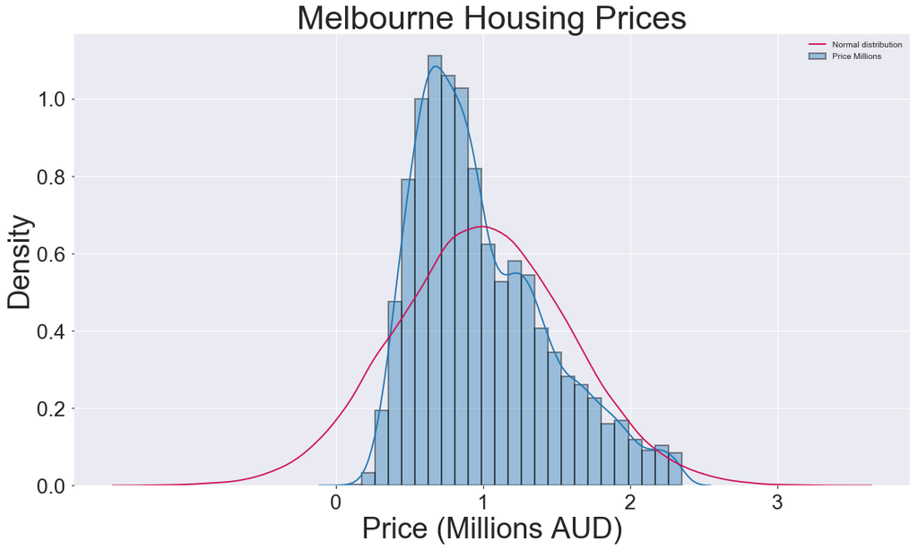

```python
# Normal distribution with same std and mean as price data
normal = np.random.normal(loc=.9978982,scale=.5934989,size=48433)

# Histogram settings
plt.figure(figsize = (18, 10))
plt.rcParams["axes.labelsize"] = 35
plt.title('Melbourne Housing Prices', fontsize=40)
plt.ylabel('Density')

plt.xticks(np.arange(12), ('0', '1', '2', '3', '4', '5', '6', '7', '8', '9', '10', '11'))
price = sns.distplot(filtered['PriceMillions'], bins=25, label='Price Millions', axlabel='Price (Millions AUD)', hist_kws=dict(edgecolor="k", linewidth=2))
normalprice = sns.distplot(normal, hist=False, bins=25, color='#ce1256', label='Normal distribution')
normalprice.tick_params(labelsize=25)
plt.legend(fontsize = 10)
plt.show()
```

### This graph shows the Histogram plot of the Price in Millions having KDE(Kernel Distribution Estimatio) plot within which best represent the data distribustion and moreover the red line is of normal distribution

**Change in the seling Prices over the span of 2 years from 2016-2018**

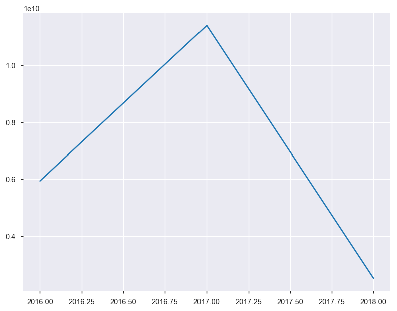

```python
sell_price_each_year = filtered.groupby(by = ['Year'])['Price'].sum()
plt.figure(figsize=(9,7), dpi=105)
# plt.xticks(ticks=['2016', '2017', '2018'], ('2016', '2017', '2018'))
plt.plot(sell_price_each_year)
plt.show()
```

#### Lets do some analysis with the coucil area and region name

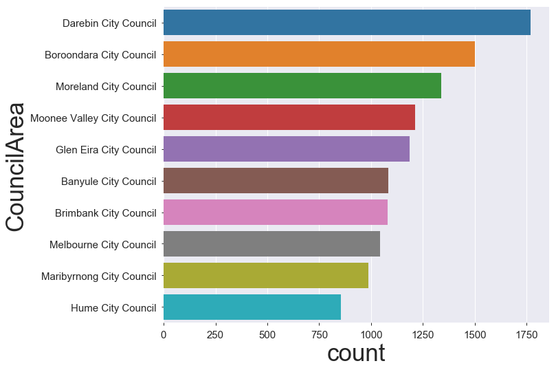

```python
sns.catplot(y='CouncilArea', kind='count', height=7, aspect=1.5, order=filtered.CouncilArea.value_counts().iloc[:10].index,  data=filtered)
plt.xticks(size=15)
plt.yticks(size=15)
```

**The Above graph shows the top 10 council area having the most number of homes**

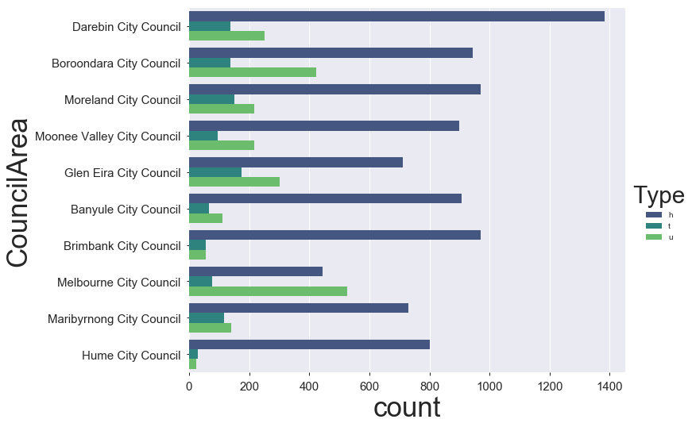

```python
sns.catplot(y='CouncilArea',hue = ('Type'), kind='count', height=7, aspect=1.5, order=filtered.CouncilArea.value_counts().iloc[:10].index,  data=filtered, palette=p4)
plt.xticks(size=15)
plt.yticks(size=15)
```

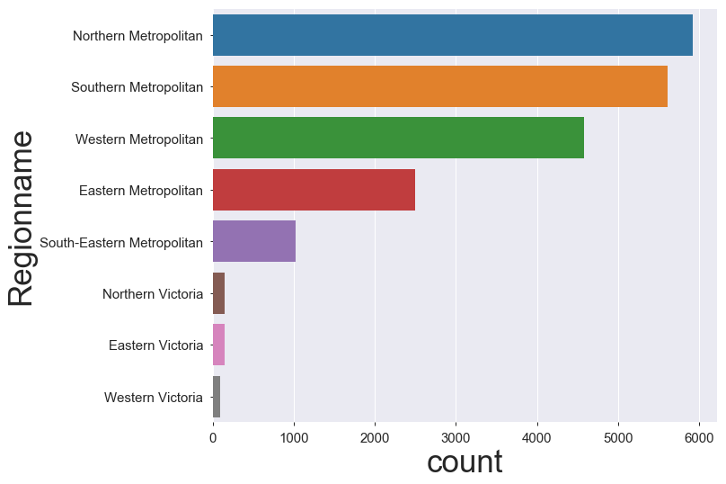

```python
sns.catplot(y='Regionname', kind='count', height=7, aspect=1.5, order=filtered.Regionname.value_counts().index,  data=filtered)
plt.xticks(size=15)
plt.yticks(size=15)
```

**The Above Plot Shows All the Regioname In ordered form Having most number of houses from most to least**

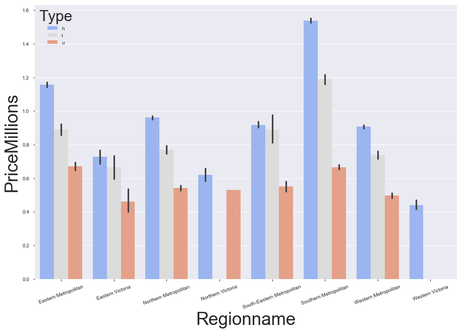

```python
fig = plt.figure(figsize=(15,10))
ax = sns.barplot(x="Regionname", y="PriceMillions", data=filtered, estimator=np.mean, hue='Type', palette=p5)
plt.xticks(rotation = 20)
```

### Lets Talk about rooms how the price gets affected with number of rooms

```python
room_price = filtered.groupby(by = 'Rooms', as_index=False).mean()
room_price = room_price.reset_index()
room_price = room_price.sort_values(by =['Price'], ascending=False, ).head(10)
# g.drop(columns=['index'], inplace = True)
room_price.reset_index(drop=True, inplace=True)
room_price.drop(columns=['index'], inplace = True)
```

SCATER PLOT OF ROOMS VS PRICE

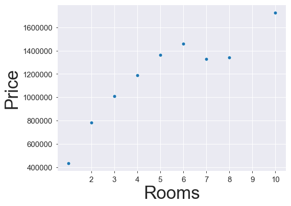

```python
room_price =room_price[room_price['Rooms']<=10]
fig = plt.figure(figsize=(8,6))
sns.scatterplot(x=room_price['Rooms'],y = room_price['Price'], palette=p4)
plt.xticks(np.arange(2,11))
plt.xticks(size=15)
plt.yticks(size=15)
```

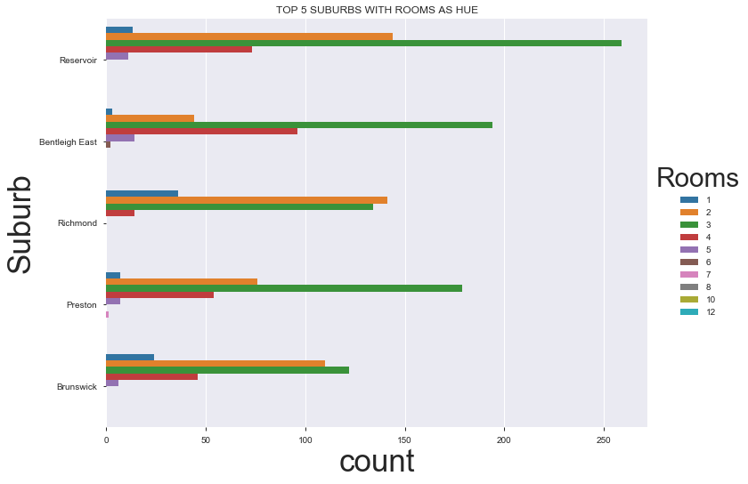

```python
# fig
fig = plt.figure(figsize=(10,8))
# plt.barh(y = f['Suburb'], width = f['Price'])
sns.catplot(y='Suburb', kind='count', height=7, aspect=1.5, order=filtered.Suburb.value_counts().iloc[:5].index,  data=filtered, hue = 'Rooms')
plt.title("TOP 5 SUBURBS WITH ROOMS AS HUE")
plt.show()
```

### Below Graph shows the number of houses sold in each month in the span of 2 years

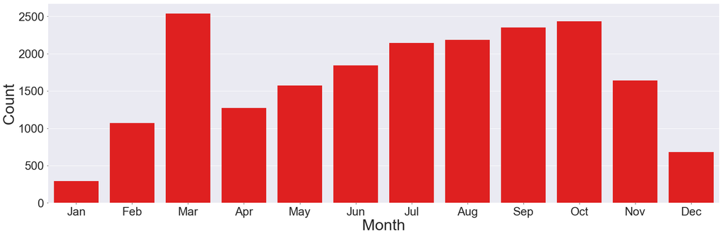

```python
Months = ['Jan','Feb','Mar','Apr','May','Jun','Jul','Aug','Sep','Oct','Nov','Dec']

sns.catplot(x='Month',
           kind='count',
            height=8.27,
            aspect=3,
            color='red',
           data=filtered)
plt.xticks(np.arange(12), Months, size=30)

# plt.xticks(size=30)
plt.yticks(size=30)
plt.xlabel('Month', fontsize=40)
plt.ylabel('Count', fontsize=40)
```

**As you can see that the most houses were sold in the month of March followed by september and october later in those years.**

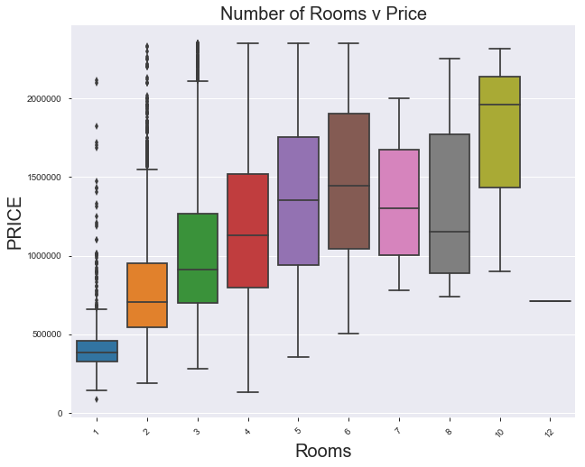

```python
fig = plt.figure(figsize=(10,8))
sns.boxplot(x = 'Rooms', y = 'Price', data = filtered)
plt.xlabel('Rooms', fontsize = 20)
plt.ylabel('PRICE', fontsize = 20)
plt.xticks(rotation = 45)
#axes[1,0].set_ylabel('Price')
plt.title('Number of Rooms v Price',  fontsize = 20)
```

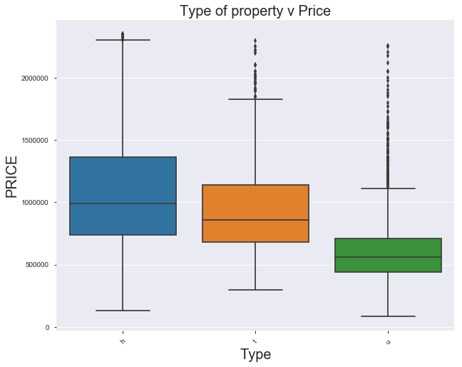

```python
# fig, ax = plt.subplots(1, 2, figsize=(10, 4))
# ax = plt.axes()
fig = plt.figure(figsize=(10,8))
sns.boxplot(x = 'Type', y = 'Price', data = filtered)
plt.xlabel('Type', fontsize = 20)
plt.ylabel('PRICE', fontsize = 20)
plt.xticks(rotation = 45)
# ax.set_xticklabels(fontsize=12)
#axes[1,0].set_ylabel('Price')
plt.title('Type of property v Price',  fontsize = 20)
```

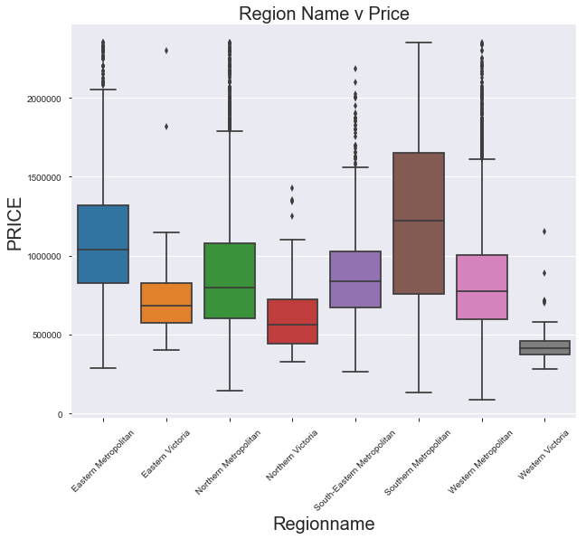

```python
fig = plt.figure(figsize=(10,8))
sns.boxplot(x = 'Regionname', y = 'Price', data = filtered)
plt.xlabel('Regionname', fontsize = 20)
plt.ylabel('PRICE', fontsize = 20)
plt.xticks(rotation = 45)
#axes[1,0].set_ylabel('Price')
plt.title('Region Name v Price',  fontsize = 20)
```

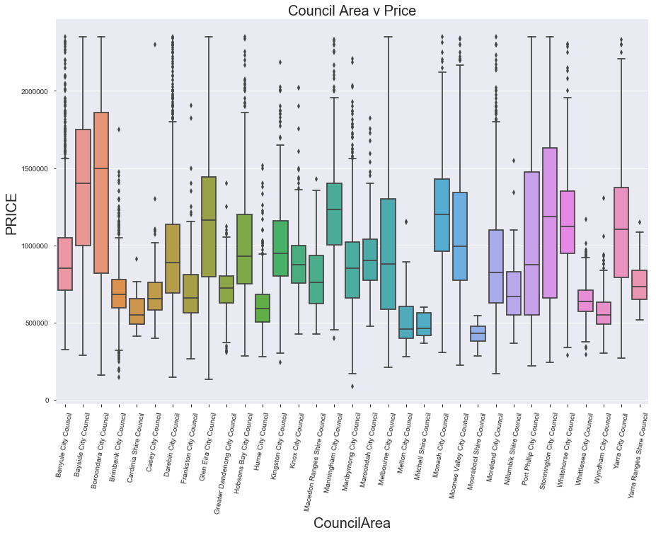

```python
fig = plt.figure(figsize=(15,10))
sns.boxplot(x = 'CouncilArea', y = 'Price', data = filtered)
plt.xlabel('CouncilArea', fontsize = 20)
plt.ylabel('PRICE', fontsize = 20)
plt.xticks(rotation = 80)
#axes[1,0].set_ylabel('Price')
plt.title('Council Area v Price',  fontsize = 20)
```

**Insights**

## Conclusions:

**This EDA just scratches the surface of the dataset. Further analyses could explore how the pricesof different types of Houses vary in time and space.**